# QUESTION 1

# QUESTION 7

Create a vertical bar chart comparing the number of marriages and divorces per capita in the U.S. between 1900, 1950, and 2000. Don't forget to label your axes!

```python
import pandas as pd
import matplotlib.pyplot as plt

# Load the dataset
file_path = "C:/Users/chikw/Downloads/us-marriages-divorces-1867-2014.csv"
df = pd.read_csv(file_path)

# Filter data for years 1900, 1950, and 2000
years_of_interest = [1900, 1950, 2000]
df_filtered = df[df['Year'].isin(years_of_interest)]
```

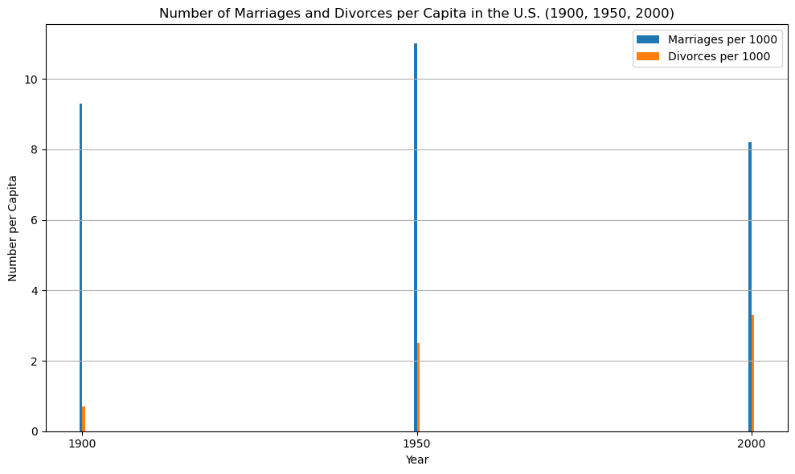

```python
# Plot the data
plt.figure(figsize=(10, 6))
plt.bar(df_filtered['Year'] - 0.2, df_filtered['Marriages_per_1000'], width=0.4, label='Marriages per 1000')
plt.bar(df_filtered['Year'] + 0.2, df_filtered['Divorces_per_1000'], width=0.4, label='Divorces per 1000')

# Add title and labels
plt.title('Number of Marriages and Divorces per Capita in the U.S. (1900, 1950, 2000)')
plt.xlabel('Year')
plt.ylabel('Number per Capita')

# Add legend
plt.legend()

# Show plot
plt.xticks(years_of_interest)
plt.grid(axis='y')
plt.tight_layout()
plt.show()
```

# QUESTION 8

Create a horizontal bar chart that compares the deadliest actors in Hollywood. Sort the actors by their kill count and label each bar with the corresponding actor's name. Don't forget to label your axes!

```python
data = pd.read_csv('C:/Users/chikw/Downloads/actor_kill_counts.csv')
newData = data.sort_values("Count", ascending = True)
newData
```

|  | Actor | Count |
| --- | --- | --- |
| 9 | Wesley Snipes | 193 |
| 3 | Clive Owen | 194 |
| 5 | Jet Li | 201 |
| 6 | Nicolas Cage | 204 |
| 2 | Clint Eastwood | 207 |
| 8 | Tomisaburo Wakayama | 226 |
| 4 | Dolph Lundgren | 239 |
| 7 | Sylvester Stallone | 267 |
| 1 | Chow Yun-Fat | 295 |
| 0 | Arnold Schwarzenegger | 369 |

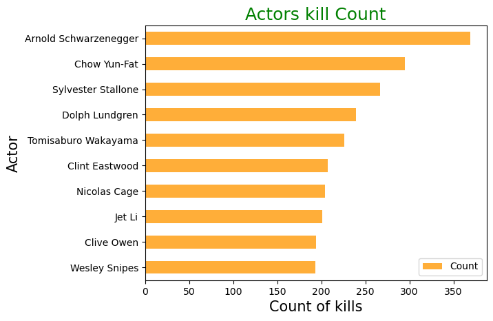

```python
newData.plot.barh(x='Actor', y='Count', color = '#FFAE39')
plt.title('Actors kill Count', fontsize = 18, color = 'Green')
plt.xlabel('Count of kills', color = 'Black', fontsize = 15)
plt.ylabel('Actor', color = 'Black', fontsize = 15)
```

# QUESTION 9

Create a pie chart showing the fraction of all Roman Emperors that were assassinated. Make sure that the pie chart is an even circle, labels the categories, and shows the percentage breakdown of the categories.

```python
import pandas as pd

# Load the data from the CSV file
data = pd.read_csv('C:/Users/chikw/Downloads/roman-emperor-reigns.csv')
data.head()
```

|  | Emperor | Length_of_Reign | Cause_of_Death |
| --- | --- | --- | --- |
| 0 | Augustus | 40.58 | Possibly assassinated |
| 1 | Tiberius | 22.50 | Possibly assassinated |
| 2 | Caligula | 4.83 | Assassinated |
| 3 | Claudius | 13.75 | Possibly assassinated |
| 4 | Nero | 13.67 | Suicide |

```python
import matplotlib.pyplot as plt
import seaborn as sns
%matplotlib inline
sns.set()

newdata = data.groupby("Cause_of_Death")['Emperor'].count()
newdata
```

```
Cause_of_Death
Assassinated             22
Died in captivity         1
Executed                  3
Illness                   5
Killed in battle          8
Natural causes           16
Possibly assassinated     8
Suicide                   5
Name: Emperor, dtype: int64
```

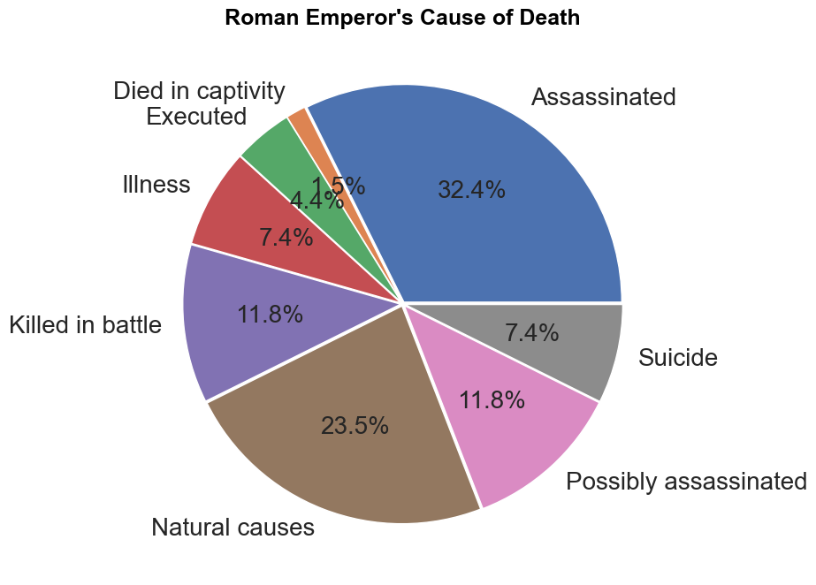

```python
newdata.plot.pie(autopct="%.1f%%", figsize = (8,8), fontsize = 20, ylabel = '', explode = [0.01]*8)
plt.title("Roman Emperor's Cause of Death", color = 'Black', fontsize = 18, fontweight = 'bold')
```

# QUESTION 10

Create a scatter plot showing the relationship between the total revenue earned by arcades and the number of Computer Science PhDs awarded in the U.S. between 2000 and 2009. Don't forget to label your axes! Color each dot according to its year.

```python
import pandas as pd

# Load the data from the CSV file
data = pd.read_csv("C:/Users/chikw/Downloads/arcade-revenue-vs-cs-doctorates.csv")
data.head()
```

|  | Year | Total Arcade Revenue (billions) | Computer Science Doctorates Awarded (US) |
| --- | --- | --- | --- |
| 0 | 2000 | 1.196 | 861 |
| 1 | 2001 | 1.176 | 830 |
| 2 | 2002 | 1.269 | 809 |
| 3 | 2003 | 1.240 | 867 |
| 4 | 2004 | 1.307 | 948 |

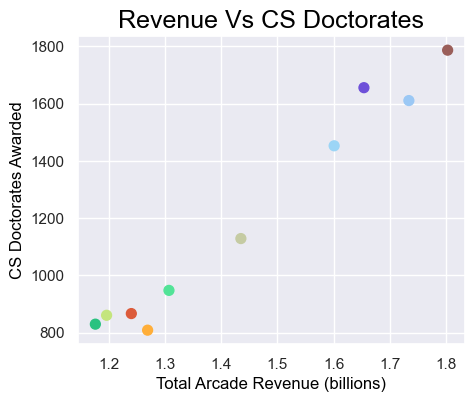

```python
import matplotlib.pyplot as pit
%matplotlib inline

colours = ['#C4E57D', '#2AC280', '#FFAE39', '#DC5B3B', '#52E397', '#C5CBA3', '#9CD5F6', '#6E50D9', '#9A5E59', '#9BC8F5']

data.plot.scatter(x = 'Total Arcade Revenue (billions)',
                 y = 'Computer Science Doctorates Awarded (US)', c = colours, s =50, figsize = (5,4))

plt.title('Revenue Vs CS Doctorates', color = 'Black', fontsize = 18)
plt.xlabel('Total Arcade Revenue (billions)', color = 'Black', fontsize = 12)
plt.ylabel('CS Doctorates Awarded', color = 'Black', fontsize = 12)
```

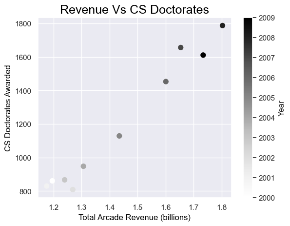

```python
data.plot.scatter(x = 'Total Arcade Revenue (billions)',
                 y = 'Computer Science Doctorates Awarded (US)', c = 'Year', s = 50)

plt.title('Revenue Vs CS Doctorates', color = 'Black', fontsize = 18)
plt.xlabel('Total Arcade Revenue (billions)', color = 'Black', fontsize = 12)
plt.ylabel('CS Doctorates Awarded', color = 'Black', fontsize = 12)
```